# Efecto de diferentes concentraciones de Cloruro de sodio sobre la germinación de Frijol (Phaseolus vulgaris) y Soja (Glycine max)

Author

Acuña Ramirez, Edinson Pooll; Hidrogo Paredes, Jhinmy Yhanner; Mondragón Herrera, Edwin; Quispe Aguilar, Alex Rolando; Rojas Campos, Griselida

# 1 Introducción

La salinidad del suelo es uno de los factores abióticos que con mayor frecuencia limita el establecimiento de los cultivos porque reduce el potencial osmótico de la solución circundante a la semilla, retrasa la fase I de imbibición y dificulta la activación de enzimas clave para la germinación (Bouzroud et al., 2023; Yadav et al., 2023).En leguminosas, grupo que incluye a la soya (Glycine max) y al frijol común (Phaseolus vulgaris) el estrés salino provoca además desbalances iónicos, acumulación de especies reactivas de oxígeno y alteraciones hormonales que comprometen la viabilidad de la plántula y, en consecuencia, el rendimiento final del cultivo (Shu et al., 2017). En frijol, concentraciones de 50 a 150 mM de NaCl reducen significativamente el porcentaje de germinación y el crecimiento inicial, con inhibición casi total a 150 mM (Mena Méndez et al., 2015).Por otro lado, la velocidad con que las semillas absorben agua es un factor decisivo cuando se combina con salinidad. Pereira y Masetto (2021) demostraron que una hidratación “rápida” en soya dispara la degradación del ADN y disminuye el vigor, mientras que una imbibición lenta preserva la integridad genómica y mejora la emergencia en campo. Estas evidencias indican que concentraciones moderadas de NaCl (50–150 mM) rango presente en suelos salinos o en aguas de riego de baja calidad son suficientes para comprometer la fase inicial de desarrollo en ambas leguminosas, y que la tasa de imbibición puede agravar o atenuar los daños. Con base en lo anterior, el presente experimento evaluará el efecto de cuatro niveles crecientes de salinidad (0, 50, 100 y 150 mM NaCl) sobre la germinación de semillas de frijol y soya, usando cinco repeticiones de 25 semillas por tratamiento.

# 2 Objetivos

## 2.1 Objetivo general

Evaluar el efecto de diferentes concentraciones de Cloruro de sodio sobre la germinación de Frijol (Phaseolus vulgaris) y Soja (Glycine max)

## 2.2 Objetivo especifico

Cuantificar el número de semillas germinadas y determinar el porcentaje de germinación de Phaseolus vulgaris y Glycine max bajo diferentes concentraciones de cloruro de sodio.

Determinar la variación de germinación en respuesta a distintas concentraciones de cloruro de sodio.

# 3 Materiales y métodos

**Obtención del material vegetal e instalación**

Se obtuvo medio kilogramo de semillas de frijol (Phaseolus vulgaris) y de soya (Glycine max) del mercado Requejo de Chachapoyas, con coordenadas 6°13’39.9”S 77°52’23.2”W, y estas fueron seleccionadas para realizar la prueba de germinación. Posteriormente, se prepararon las soluciones de cloruro de sodio en diferentes concentraciones (0, 50, 100, 150 mM). Luego, cada semilla se sembró en tapers para ver los efectos de diferentes concentraciones de cloruro de sodio. Se colocaron 25 semillas sobre papel toalla humedecido con 10 ml de solución, esta solución fue aplicada cada 48 horas. Finalmente se etiquetó con sus respectivas leyendas tanto para frijol como soja, lo cual facilitó el seguimiento más organizado y preciso del comportamiento del grupo de semillas.

**Diseño experimental**

Se evaluaron cuatro concentraciones de NaCl. El experimento se montó bajo un Diseño factorial en bloques 4 x 2, siendo el primer factor las concentraciones de NaCl (0, 50, 100 y 150 mM) y el segundo factor las especies (Frijol y soja). Habiendo un total de 8 tratamientos con 5 réplicas. En cada réplica hay 25 semillas.

**Evaluación y análisis de datos**

Los datos obtenidos se realizan a partir de las variables dependientes. Los parámetros incluyen: Semillas germinadas (grs), Germinabilidad (grp) la unidad de medición es en porcentaje (%) y la variación de germinación (vgt) donde la unidad de medición es el Tiempo (t2). Para las variables que cumplen con los supuestos de normalidad (p > 0.05) se aplicará un análisis de varianza factorial (ANOVA) para evaluar las diferencias entre tratamientos y se emplea la prueba de Tukey para comparar medias.

# 4 Resultados

## 4.1 Análisis de datos

### 4.1.1 Paquetes a cargar

```r
source("https://inkaverse.com/setup.r")
```

[output not shown]

[output not shown]

[output not shown]

[output not shown]

[output not shown]

[output not shown]

[output not shown]

[output not shown]

[output not shown]

```r
library(GerminaR)
library(dplyr)
library(agricolae)
```

### 4.1.2 Importar datos

```r
url <- "https://docs.google.com/spreadsheets/d/1clA0TdvpeIv2PDiLcT7SQB4Aiy-Bbx2BUDXObOCL2R4/edit?usp=sharing"

gs <- as_sheets_id(url)

fb <- range_read(gs
                 , sheet = "fb") %>%
  mutate(across(c(NaCl, Especie, block), as.factor)) %>%
  as.data.frame()

str(fb)
## 'data.frame':    40 obs. of  13 variables:
##  $ plots  : chr  "101" "102" "103" "104" ...
##  $ ntreat : chr  "4" "7" "8" "3" ...
##  $ NaCl   : Factor w/ 4 levels "0.mM","100.mM",..: 3 2 3 2 4 4 1 1 2 4 ...
##  $ Especie: Factor w/ 2 levels "Frijol","Soja": 1 2 2 1 1 2 1 2 1 2 ...
##  $ block  : Factor w/ 5 levels "1","2","3","4",..: 1 1 1 1 1 1 1 1 2 2 ...
##  $ seed   : num  25 25 25 25 25 25 25 25 25 25 ...
##  $ d0     : num  0 0 0 0 0 0 0 0 0 0 ...
##  $ d1     : num  3 0 0 3 3 0 3 0 3 0 ...
##  $ d2     : num  5 0 0 6 5 0 6 0 6 0 ...
##  $ d3     : num  7 0 0 8 7 0 8 0 8 0 ...
##  $ d4     : num  3 0 0 3 3 0 3 0 3 0 ...
##  $ d5     : num  2 0 0 2 2 0 2 0 2 0 ...
##  $ d6     : num  3 0 0 3 3 0 3 0 3 0 ...
```

### 4.1.3 Conjunto de datos

```r
gsm <- ger_summary(SeedN = "seed"
                   , evalName = "d"
                   , data = fb
                   )
gsm %>% kable()
```

| plots | ntreat | NaCl | Especie | block | seed | grs | grp | mgt | mgr | gsp | unc | syn | vgt | sdg | cvg |
| --- | --- | --- | --- | --- | --- | --- | --- | --- | --- | --- | --- | --- | --- | --- | --- |
| 101 | 4 | 150.mM | Frijol | 1 | 25 | 23 | 92 | 3.217391 | 0.3108108 | 31.08108 | 2.457223 | 0.1620553 | 2.450593 | 1.565437 | 48.65547 |
| 102 | 7 | 100.mM | Soja | 1 | 25 | 0 | 0 |  |  |  | 0.000000 |  | 0.000000 | 0.000000 |  |
| 103 | 8 | 150.mM | Soja | 1 | 25 | 0 | 0 |  |  |  | 0.000000 |  | 0.000000 | 0.000000 |  |
| 104 | 3 | 100.mM | Frijol | 1 | 25 | 25 | 100 | 3.160000 | 0.3164557 | 31.64557 | 2.412879 | 0.1766667 | 2.306667 | 1.518771 | 48.06239 |
| 105 | 2 | 50.mM | Frijol | 1 | 25 | 23 | 92 | 3.217391 | 0.3108108 | 31.08108 | 2.457223 | 0.1620553 | 2.450593 | 1.565437 | 48.65547 |
| 106 | 6 | 50.mM | Soja | 1 | 25 | 0 | 0 |  |  |  | 0.000000 |  | 0.000000 | 0.000000 |  |
| 107 | 1 | 0.mM | Frijol | 1 | 25 | 25 | 100 | 3.160000 | 0.3164557 | 31.64557 | 2.412879 | 0.1766667 | 2.306667 | 1.518771 | 48.06239 |
| 108 | 5 | 0.mM | Soja | 1 | 25 | 0 | 0 |  |  |  | 0.000000 |  | 0.000000 | 0.000000 |  |
| 201 | 3 | 100.mM | Frijol | 2 | 25 | 25 | 100 | 3.160000 | 0.3164557 | 31.64557 | 2.412879 | 0.1766667 | 2.306667 | 1.518771 | 48.06239 |
| 202 | 6 | 50.mM | Soja | 2 | 25 | 0 | 0 |  |  |  | 0.000000 |  | 0.000000 | 0.000000 |  |
| 203 | 4 | 150.mM | Frijol | 2 | 25 | 21 | 84 | 3.095238 | 0.3230769 | 32.30769 | 2.457594 | 0.1571429 | 2.290476 | 1.513432 | 48.89549 |
| 204 | 2 | 50.mM | Frijol | 2 | 25 | 25 | 100 | 3.040000 | 0.3289474 | 32.89474 | 2.458689 | 0.1600000 | 2.206667 | 1.485485 | 48.86465 |
| 205 | 8 | 150.mM | Soja | 2 | 25 | 0 | 0 |  |  |  | 0.000000 |  | 0.000000 | 0.000000 |  |
| 206 | 1 | 0.mM | Frijol | 2 | 25 | 25 | 100 | 3.160000 | 0.3164557 | 31.64557 | 2.412879 | 0.1766667 | 2.306667 | 1.518771 | 48.06239 |
| 207 | 7 | 100.mM | Soja | 2 | 25 | 0 | 0 |  |  |  | 0.000000 |  | 0.000000 | 0.000000 |  |
| 208 | 5 | 0.mM | Soja | 2 | 25 | 0 | 0 |  |  |  | 0.000000 |  | 0.000000 | 0.000000 |  |
| 301 | 2 | 50.mM | Frijol | 3 | 25 | 25 | 100 | 2.960000 | 0.3378378 | 33.78378 | 2.407210 | 0.1700000 | 1.956667 | 1.398809 | 47.25706 |
| 302 | 3 | 100.mM | Frijol | 3 | 25 | 25 | 100 | 3.160000 | 0.3164557 | 31.64557 | 2.412879 | 0.1766667 | 2.306667 | 1.518771 | 48.06239 |
| 303 | 5 | 0.mM | Soja | 3 | 25 | 0 | 0 |  |  |  | 0.000000 |  | 0.000000 | 0.000000 |  |
| 304 | 7 | 100.mM | Soja | 3 | 25 | 0 | 0 |  |  |  | 0.000000 |  | 0.000000 | 0.000000 |  |
| 305 | 1 | 0.mM | Frijol | 3 | 25 | 23 | 92 | 3.130435 | 0.3194444 | 31.94444 | 2.435909 | 0.1660079 | 2.118577 | 1.455533 | 46.49620 |
| 306 | 8 | 150.mM | Soja | 3 | 25 | 0 | 0 |  |  |  | 0.000000 |  | 0.000000 | 0.000000 |  |
| 307 | 4 | 150.mM | Frijol | 3 | 25 | 25 | 100 | 3.120000 | 0.3205128 | 32.05128 | 2.422825 | 0.1700000 | 2.026667 | 1.423610 | 45.62854 |
| 308 | 6 | 50.mM | Soja | 3 | 25 | 0 | 0 |  |  |  | 0.000000 |  | 0.000000 | 0.000000 |  |
| 401 | 6 | 50.mM | Soja | 4 | 25 | 0 | 0 |  |  |  | 0.000000 |  | 0.000000 | 0.000000 |  |
| 402 | 8 | 150.mM | Soja | 4 | 25 | 0 | 0 |  |  |  | 0.000000 |  | 0.000000 | 0.000000 |  |
| 403 | 2 | 50.mM | Frijol | 4 | 25 | 25 | 100 | 3.040000 | 0.3289474 | 32.89474 | 2.419471 | 0.1733333 | 2.123333 | 1.457166 | 47.93310 |
| 404 | 5 | 0.mM | Soja | 4 | 25 | 0 | 0 |  |  |  | 0.000000 |  | 0.000000 | 0.000000 |  |
| 405 | 1 | 0.mM | Frijol | 4 | 25 | 25 | 100 | 3.160000 | 0.3164557 | 31.64557 | 2.412879 | 0.1766667 | 2.306667 | 1.518771 | 48.06239 |
| 406 | 4 | 150.mM | Frijol | 4 | 25 | 24 | 96 | 3.125000 | 0.3200000 | 32.00000 | 2.443959 | 0.1630435 | 2.114130 | 1.454005 | 46.52816 |
| 407 | 7 | 100.mM | Soja | 4 | 25 | 0 | 0 |  |  |  | 0.000000 |  | 0.000000 | 0.000000 |  |
| 408 | 3 | 100.mM | Frijol | 4 | 25 | 26 | 104 | 3.269231 | 0.3058824 | 30.58824 | 2.430457 | 0.1723077 | 2.524615 | 1.588904 | 48.60176 |
| 501 | 4 | 150.mM | Frijol | 5 | 25 | 24 | 96 | 3.041667 | 0.3287671 | 32.87671 | 2.449082 | 0.1630435 | 2.215580 | 1.488482 | 48.93641 |
| 502 | 8 | 150.mM | Soja | 5 | 25 | 0 | 0 |  |  |  | 0.000000 |  | 0.000000 | 0.000000 |  |
| 503 | 2 | 50.mM | Frijol | 5 | 25 | 26 | 104 | 3.269231 | 0.3058824 | 30.58824 | 2.430457 | 0.1723077 | 2.524615 | 1.588904 | 48.60176 |
| 504 | 3 | 100.mM | Frijol | 5 | 25 | 25 | 100 | 3.160000 | 0.3164557 | 31.64557 | 2.483216 | 0.1566667 | 2.473333 | 1.572683 | 49.76846 |
| 505 | 6 | 50.mM | Soja | 5 | 25 | 0 | 0 |  |  |  | 0.000000 |  | 0.000000 | 0.000000 |  |
| 506 | 5 | 0.mM | Soja | 5 | 25 | 0 | 0 |  |  |  | 0.000000 |  | 0.000000 | 0.000000 |  |
| 507 | 7 | 100.mM | Soja | 5 | 25 | 0 | 0 |  |  |  | 0.000000 |  | 0.000000 | 0.000000 |  |
| 508 | 1 | 0.mM | Frijol | 5 | 25 | 25 | 100 | 3.320000 | 0.3012048 | 30.12048 | 2.368102 | 0.1900000 | 2.060000 | 1.435270 | 43.23102 |

```r
# Prosopis data set processed

gsm %>%
  head(6) %>%
  mutate(across(where(is.numeric), ~round(., 2))) %>%
  kable(caption = "Function ger_summary performe ten germination indices")
```

Function ger_summary performe ten germination indices

| plots | ntreat | NaCl | Especie | block | seed | grs | grp | mgt | mgr | gsp | unc | syn | vgt | sdg | cvg |
| --- | --- | --- | --- | --- | --- | --- | --- | --- | --- | --- | --- | --- | --- | --- | --- |
| 101 | 4 | 150.mM | Frijol | 1 | 25 | 23 | 92 | 3.22 | 0.31 | 31.08 | 2.46 | 0.16 | 2.45 | 1.57 | 48.66 |
| 102 | 7 | 100.mM | Soja | 1 | 25 | 0 | 0 |  |  |  | 0.00 |  | 0.00 | 0.00 |  |
| 103 | 8 | 150.mM | Soja | 1 | 25 | 0 | 0 |  |  |  | 0.00 |  | 0.00 | 0.00 |  |
| 104 | 3 | 100.mM | Frijol | 1 | 25 | 25 | 100 | 3.16 | 0.32 | 31.65 | 2.41 | 0.18 | 2.31 | 1.52 | 48.06 |
| 105 | 2 | 50.mM | Frijol | 1 | 25 | 23 | 92 | 3.22 | 0.31 | 31.08 | 2.46 | 0.16 | 2.45 | 1.57 | 48.66 |
| 106 | 6 | 50.mM | Soja | 1 | 25 | 0 | 0 |  |  |  | 0.00 |  | 0.00 | 0.00 |  |

```r
view (gsm)
```

### 4.1.4 Semillas germinadas (grs)

```r
# analysis of variance

av <- aov(grs ~ block + NaCl*Especie, data = gsm)
summary(av)
##              Df Sum Sq Mean Sq   F value              Pr(>F)
## block         4      2       0     0.875               0.491
## NaCl          3      5       2     2.625               0.070 .
## Especie       1   6003    6003 10504.375 <0.0000000000000002 ***
## NaCl:Especie  3      4       1     2.625               0.070 .
## Residuals    28     16       1
## ---
## Signif. codes:  0 '***' 0.001 '**' 0.01 '*' 0.05 '.' 0.1 ' ' 1
# mean comparison test

mc_grs <- ger_testcomp(aov = av
                       , comp = c("NaCl", "Especie")
                       , type = "tukey"
                       )

# data result

mc_grs$table %>%
   kable(caption = "Germinated seeds")
```

Germinated seeds

| NaCl | Especie | grs | std | r | ste | se | min | max | sig |
| --- | --- | --- | --- | --- | --- | --- | --- | --- | --- |
| 0.mM | Frijol | 24.6 | 0.8944272 | 5 | 0.4000000 | 0.3380617 | 23 | 25 | ab |
| 0.mM | Soja | 0.0 | 0.0000000 | 5 | 0.0000000 | 0.3380617 | 0 | 0 | c |
| 100.mM | Frijol | 25.2 | 0.4472136 | 5 | 0.2000000 | 0.3380617 | 25 | 26 | a |
| 100.mM | Soja | 0.0 | 0.0000000 | 5 | 0.0000000 | 0.3380617 | 0 | 0 | c |
| 150.mM | Frijol | 23.4 | 1.5165751 | 5 | 0.6782330 | 0.3380617 | 21 | 25 | b |
| 150.mM | Soja | 0.0 | 0.0000000 | 5 | 0.0000000 | 0.3380617 | 0 | 0 | c |
| 50.mM | Frijol | 24.8 | 1.0954451 | 5 | 0.4898979 | 0.3380617 | 23 | 26 | ab |
| 50.mM | Soja | 0.0 | 0.0000000 | 5 | 0.0000000 | 0.3380617 | 0 | 0 | c |

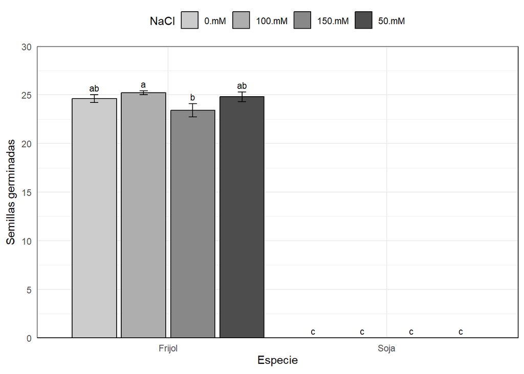

```r
# bar graphics for germination percentage

grs <- mc_grs$table %>%
   fplot(data = .
       , type = "bar"
       , x = "Especie"
       , y = "grs"
       , group = "NaCl"
       , ylimits = c(0, 30, 5)
       , ylab = "Semillas germinadas"
       , xlab = "Especie"
       , glab = "NaCl"
       , error = "ste"
       , sig = "sig"
       , color = F
       )

grs
```

### 4.1.5 Germinabilidad o porcentaje de germinación (grp)

```r
# analysis of variance

av <- aov(grp ~ block + NaCl*Especie, data = gsm)
summary(av)
##              Df Sum Sq Mean Sq   F value              Pr(>F)
## block         4     32       8     0.875               0.491
## NaCl          3     72      24     2.625               0.070 .
## Especie       1  96040   96040 10504.375 <0.0000000000000002 ***
## NaCl:Especie  3     72      24     2.625               0.070 .
## Residuals    28    256       9
## ---
## Signif. codes:  0 '***' 0.001 '**' 0.01 '*' 0.05 '.' 0.1 ' ' 1
# mean comparison test

mc_grp <- ger_testcomp(aov = av
                       , comp = c("NaCl", "Especie")
                       , type = "tukey"
                       )

# data result

mc_grp$table %>%
   kable(caption = "Germination percentage mean comparision")
```

Germination percentage mean comparision

| NaCl | Especie | grp | std | r | ste | se | min | max | sig |
| --- | --- | --- | --- | --- | --- | --- | --- | --- | --- |
| 0.mM | Frijol | 98.4 | 3.577709 | 5 | 1.600000 | 1.352247 | 92 | 100 | ab |
| 0.mM | Soja | 0.0 | 0.000000 | 5 | 0.000000 | 1.352247 | 0 | 0 | c |
| 100.mM | Frijol | 100.8 | 1.788854 | 5 | 0.800000 | 1.352247 | 100 | 104 | a |
| 100.mM | Soja | 0.0 | 0.000000 | 5 | 0.000000 | 1.352247 | 0 | 0 | c |
| 150.mM | Frijol | 93.6 | 6.066300 | 5 | 2.712932 | 1.352247 | 84 | 100 | b |
| 150.mM | Soja | 0.0 | 0.000000 | 5 | 0.000000 | 1.352247 | 0 | 0 | c |
| 50.mM | Frijol | 99.2 | 4.381780 | 5 | 1.959592 | 1.352247 | 92 | 104 | ab |
| 50.mM | Soja | 0.0 | 0.000000 | 5 | 0.000000 | 1.352247 | 0 | 0 | c |

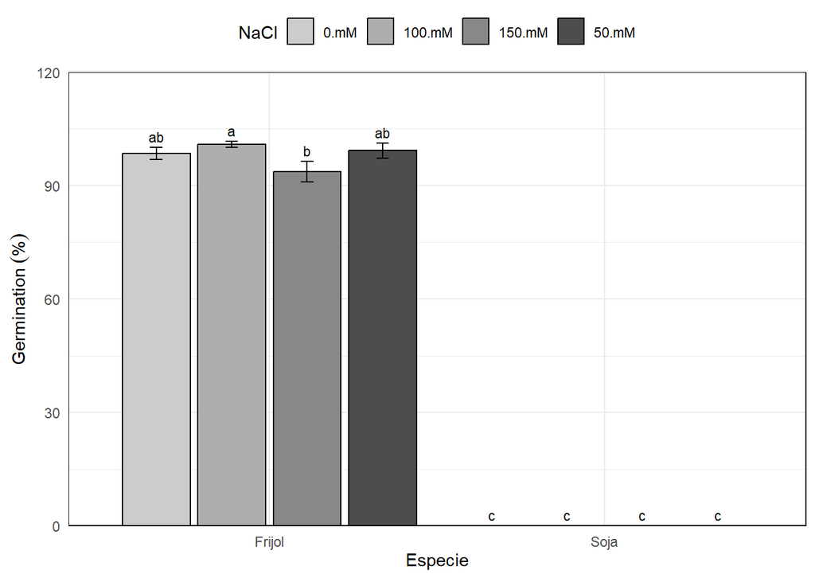

```r
# bar graphics for germination percentage

grp <- mc_grp$table %>%
   fplot(data = .
       , type = "bar"
       , x = "Especie"
       , y = "grp"
       , group = "NaCl"
       , ylimits = c(0, 120, 30)
       , ylab = "Germination ('%')"
       , xlab = "Especie"
       , glab = "NaCl"
       , error = "ste"
       , sig = "sig"
       , color = F
       )

grp
```

### 4.1.6 Variación de germinación (vgt)

```r
## Germination variance (vgt)

# analysis of variance

av <- aov(vgt ~ block + NaCl*Especie, data = gsm)
summary(av)
##              Df Sum Sq Mean Sq  F value              Pr(>F)
## block         4   0.08    0.02    1.716               0.174
## NaCl          3   0.05    0.02    1.234               0.316
## Especie       1  51.47   51.47 4169.203 <0.0000000000000002 ***
## NaCl:Especie  3   0.05    0.02    1.234               0.316
## Residuals    28   0.35    0.01
## ---
## Signif. codes:  0 '***' 0.001 '**' 0.01 '*' 0.05 '.' 0.1 ' ' 1

# mean comparison test

mc_vgt <- ger_testcomp(aov = av
                       , comp = c("NaCl", "Especie")
                       , type = "tukey")

# data result

mc_vgt$table %>%
   kable(caption = "Germination variance")
```

Germination variance

| NaCl | Especie | vgt | std | r | ste | se | min | max | sig |
| --- | --- | --- | --- | --- | --- | --- | --- | --- | --- |
| 0.mM | Frijol | 2.219715 | 0.1208507 | 5 | 0.0540461 | 0.0496916 | 2.060000 | 2.306667 | a |
| 0.mM | Soja | 0.000000 | 0.0000000 | 5 | 0.0000000 | 0.0496916 | 0.000000 | 0.000000 | b |
| 100.mM | Frijol | 2.383590 | 0.1068803 | 5 | 0.0477983 | 0.0496916 | 2.306667 | 2.524615 | a |
| 100.mM | Soja | 0.000000 | 0.0000000 | 5 | 0.0000000 | 0.0496916 | 0.000000 | 0.000000 | b |
| 150.mM | Frijol | 2.219489 | 0.1633588 | 5 | 0.0730563 | 0.0496916 | 2.026667 | 2.450593 | a |
| 150.mM | Soja | 0.000000 | 0.0000000 | 5 | 0.0000000 | 0.0496916 | 0.000000 | 0.000000 | b |
| 50.mM | Frijol | 2.252375 | 0.2343019 | 5 | 0.1047830 | 0.0496916 | 1.956667 | 2.524615 | a |
| 50.mM | Soja | 0.000000 | 0.0000000 | 5 | 0.0000000 | 0.0496916 | 0.000000 | 0.000000 | b |

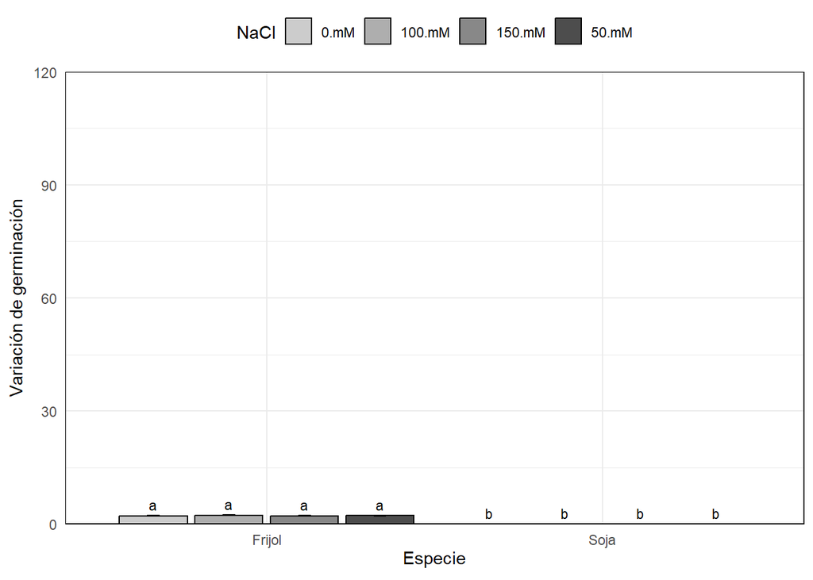

```r
# bar graphics for variance germination variance

vgt <- mc_vgt$table %>%
   fplot(data = .
       , type = "bar"
       , x = "Especie"
       , y = "vgt"
       , group = "NaCl"
       , ylimits = c(0, 120, 30)
       , ylab = "Variación de germinación"
       , xlab = "Especie"
       , glab = "NaCl"
       , error = "ste"
       , sig = "sig"
       , color = F
       )

vgt
```

## 4.2 Análisis acumulativo de la germinación

### 4.2.1 Análisis en el tiempo para especie

```r
# data frame with percentage or relative germination in time by especie

git <- ger_intime(Factor = "Especie"
                  , SeedN = "seed"
                  , evalName = "d"
                  , method = "percentage"
                  , data = fb
                  )

# data result

git %>%
   head(6) %>%
   kable(caption = "Cumulative germination by especie factor")
```

Cumulative germination by especie factor

| Especie | evaluation | mean | r | std | min | max | ste |
| --- | --- | --- | --- | --- | --- | --- | --- |
| Frijol | 0 | 0.0 | 20 | 0.000000 | 0 | 0 | 0.0000000 |
| Soja | 0 | 0.0 | 20 | 0.000000 | 0 | 0 | 0.0000000 |
| Frijol | 1 | 12.8 | 20 | 2.092593 | 8 | 16 | 0.4679181 |
| Soja | 1 | 0.0 | 20 | 0.000000 | 0 | 0 | 0.0000000 |
| Frijol | 2 | 35.2 | 20 | 2.783409 | 28 | 40 | 0.6223893 |
| Soja | 2 | 0.0 | 20 | 0.000000 | 0 | 0 | 0.0000000 |

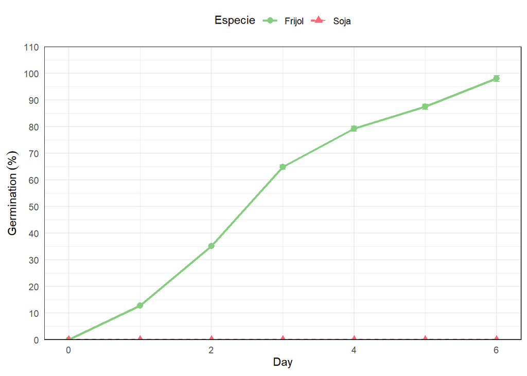

```r
# graphic germination in time by Especie

Especie <- git %>%
   fplot(data = .
        , type = "line"
        , x = "evaluation"
        , y = "mean"
        , group = "Especie"
        , ylimits = c(0, 110, 10)
        , ylab = "Germination ('%')"
        , xlab = "Day"
        , glab = "Especie"
        , color = T
        , error = "ste"
        )
Especie
```

## 4.3 Gráficos

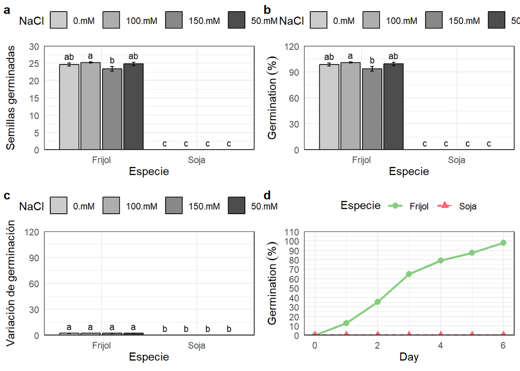

```r
install.packages("cowplot")
library(cowplot)

## graficos

class(grs)
## [1] "gg"     "ggplot"
class(grp)
## [1] "gg"     "ggplot"
class(vgt)
## [1] "gg"     "ggplot"
class(Especie)
## [1] "gg"     "ggplot"

## Combinar gráficos

figura_completa <- plot_grid(grs, grp, vgt, Especie,
                             labels = c("a", "b", "c", "d"),
                             ncol = 2,
                             rel_widths = c(1, 1),
                             rel_heights = c(1, 1),
                             align = "hv",
                             label_size = 12)

# Mostrar la figura
print(figura_completa)
```

```r
# Guardar figura

ggsave("Análisis_ger.png", figura_completa, width = 12, height = 8)
```

En el experimento, se observó que las semillas de soja no germinaron en ninguno de los tratamientos, incluido el control. Solo ha germinado el frijol.

[figure not shown]

Tabla de resultados

**Semillas germinadas (grs)**

**Germinabilidad (grp)**

**Variación de germinación**